# Analiza populacji psów w Zurychu w latach 2015-2023

Marta Dziel

26.05.2023

## 1. Dane źródłowe

Do poniższej analizy wykorzystana została baza danych udostępniona publicznie przez Urząd Miasta w Zurychu pod poniższym linkiem

https://data.stadt-zuerich.ch/dataset/sid_stapo_hundebestand_od1001

## 2. Populacja psów w Zurychu - zmiany w latach 2015 - 2023

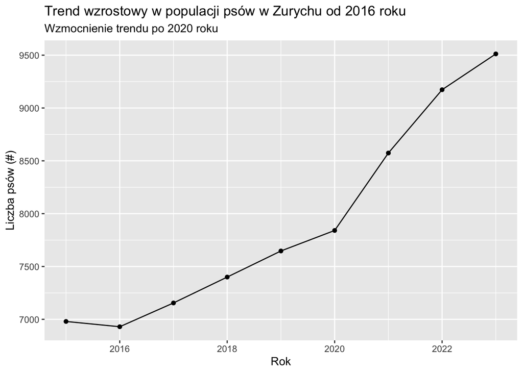

2. Wykres: Populacja psów w Zurychu w latach 2015 - 2023

Na powyższym wykresie widać trend wzrostowy w populacji psów w Zurychu - wartości rosły już między latami 2016 - 2019, natomiast widać znaczny wzrost tej tendencji po roku 2020. Prawdopodobnie jest to spowodowane zmianą trybu życia wywołaną przez pandemię.

W latach 2022-2023 widać w dalszym ciągu tendencję wzrostową, jednakże nie jest ona aż tak silna jak w dwóch poprzednich latach - co może wskazywać na np. konieczność powrotu pracowników do biura, co ma realny wpływ na decyzje o posiadaniu psa.

## 3. Populacja psów w Zurychu w podziale na psy rasowe vs psy rasy mieszanej

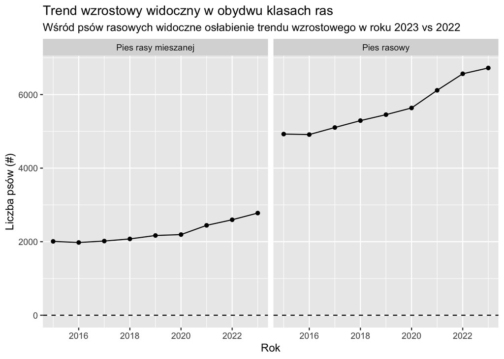

3.1. Wykres: Populacja psów w Zurychu w podziale na psy rasowe vs psy rasy mieszanej, w latach 2015 - 2023

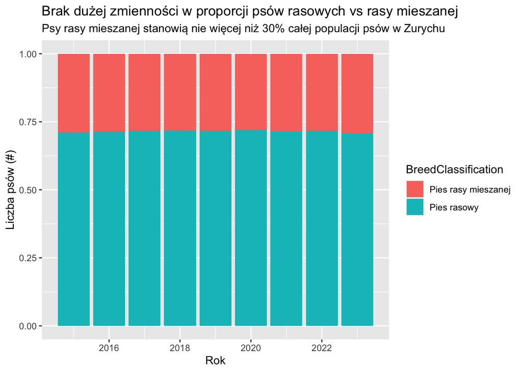

3.2. Wykres: Rozkład proporcji pomiędzy psami rasowymi a psami rasy mieszanej, w latach 2015 - 2023

#### Wnioski:

1. Kategoria psów rasowych jest zdecydowanie liczniejsza niż kategoria psów rasy mieszanej (ok. 70% psów rasowych vs ok. 30% psów rasy mieszanej)
2. Powyżej wspomniana proporcja utrzymywana jest przez cały badany okres
3. Widoczny trend wzrostowy w liczbie posiadanych psów w obydwu kategoriach; w obydwu kategoriach trend ten został wzmocniony w latach 2020 - 2022. Natomiast w przypadku psów rasowych, wzrost między rokiem 2022-2023 nie jest już aż tak wysoki jak w przypadku okresu 2020-2022.

## 4. Populacja psów w Zurychu w podziale na płeć

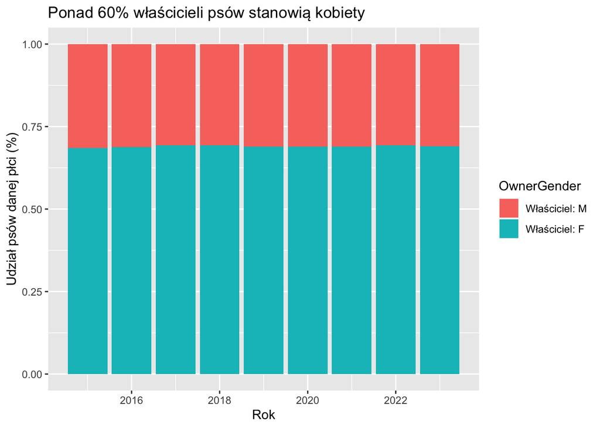

4.1. Wykres: Populacja psów w Zurychu w podziale na płeć właściciela, w latach 2015 - 2023

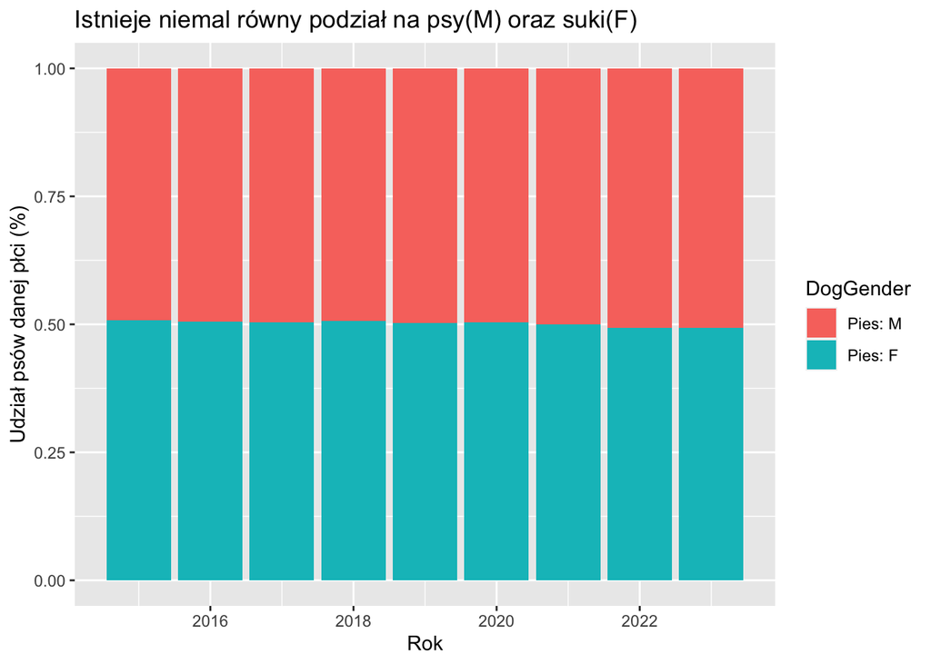

4.2. Wykres: Populacja psów w Zurychu w podziale na płeć psa, w latach 2015 - 2023

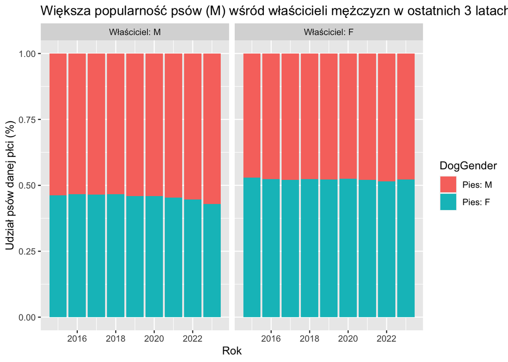

4.3. Wykres: Populacja psów w Zurychu w podziale na płeć psa oraz właściciela, w latach 2015 - 2023

#### Wnioski:

1. W Zurychu więcej kobiet posiada psy (ponad 60%)
2. Kobiety jedynie w niewielkim stopniu wybierają częściej suki(F), natomiast mężczyźni również jedynie w niewielkim stopniu częściej wybierają psy.
3. W ostatnich 3 latach widać większą preferencję właścicieli mężczyzn do wyboru psów (M).

## 5. Populacja psów w Zurychu w podziale na grupy wiekowe właścicieli - w okresie 2015 - 2023

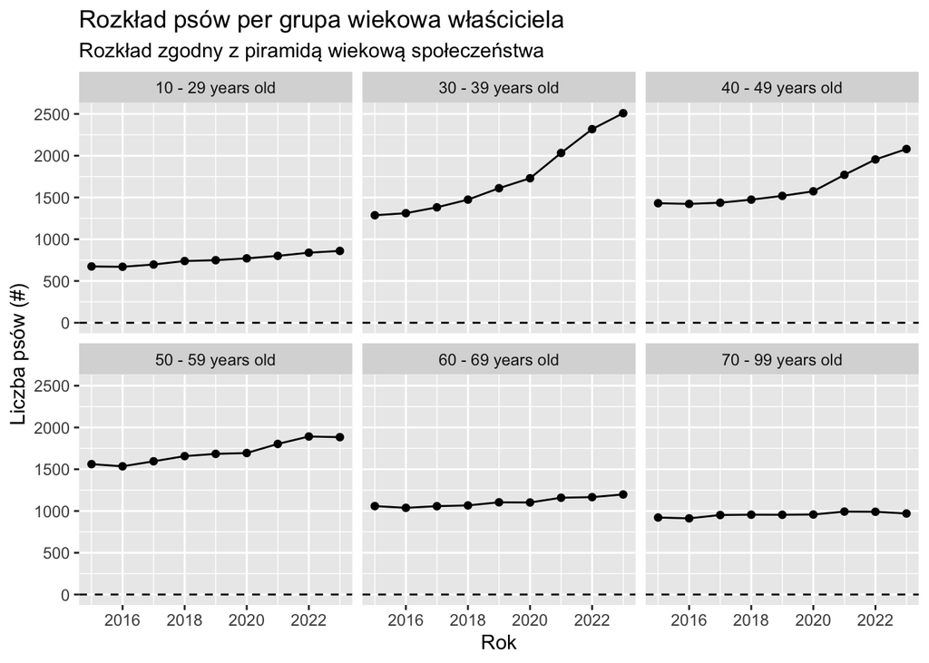

5. Wykres: Populacja psów w Zurychu w podziale na grupy wiekowe właścicieli, w okresie 2015 - 2023

#### Wnioski:

1. W każdej z analizowanych grup wiekowych widoczny jest trend wzrostowy w liczbie posiadanych psów w okresie 2015 - 2023
2. Grupy wiekowe: 30-39 lat, 40-49 lat, 50-59 lat są grupami z największą liczbą psów (w ciągu całego badanego okresu) - co jest zgodne z piramidą wiekową społeczeństwa
3. W grupach wymienionych w pkt. 2. widoczne jest znaczne wzmocnienie trendu wzrostowego w latach 2020-2022
4. W grupach wymienionych w pkt. 2. widoczne jest osłabienie trendu wzrostowego w latach 2022-2023

## 6. Populacja psów w Zurychu w podziale na wiek psów - w okresie 2015 - 2023

### 6.1. Przekrój danych w podziale na wiek psa, dla roku 2023

Istnieje aż 23 kategorii wiekowych psów. Dla zwiększenia przejrzystości analizy, dane zostały pogrupowane w 5 kategorii wiekowych (uwaga: nie są to grupy równe pod względem uwzględnionych lat per grupa)

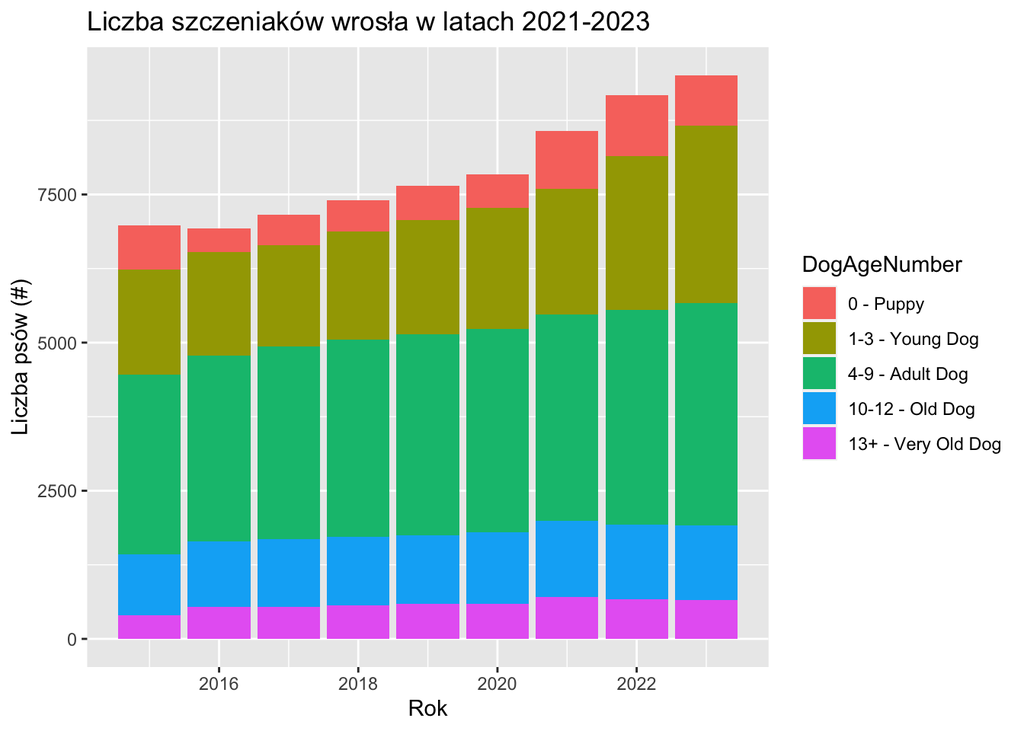

6. Wykres: Rozkład liczebności psów pod kątem ich wieku w latach 2015-2023

Analizując rozkład liczebności psów pod kątem ich wieku widać, że najwięcej psów jest w przedziale wiekowym 4-9 lat (pies dorosły) oraz 1-3 (młody pies). W latach 2021 oraz 2022 widac było też znaczny wzrost liczby szczeniaków (poniżej 1 roku). Taki rozkład wieku wśród populacji psów w Zurychu może być informacją istotną dla osób, które zastanawiają się nad prowadzeniem biznesu związanego z psami - szkolenia, fryzjer, sklepy z akcesoriami, itd.

## 7. Populacja psów w Zurychu w podziale na rasy psów - w okresie 2015 - 2023

W rejestrze psów w Zurychu widnieje 394 ras psów - z tego powodu, do dalszej analizy wybranych zostało top 10 ras psów zarejestrowanych w 2023 roku (Sprawdzane pod kątem kryterium “Primary Breed” która mówi o dominującej rasie - co oznacza, że analiza zostanie przeprowadzona zarówno na psach rasowych jak i psach rasy mieszanej).

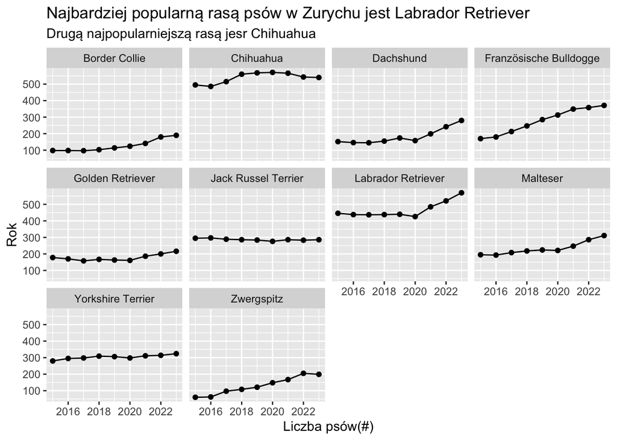

7. Wykres: 10 najpopularniejszych ras psów w roku 2023 z uwzględnieniem linii trendu w latach poprzednich

## 8. Analiza liczebności szczeniaków w latach 2015-2023

### 8.1. Populacja szczeniaków w Zurychu - zmiany w latach 2015 - 2023

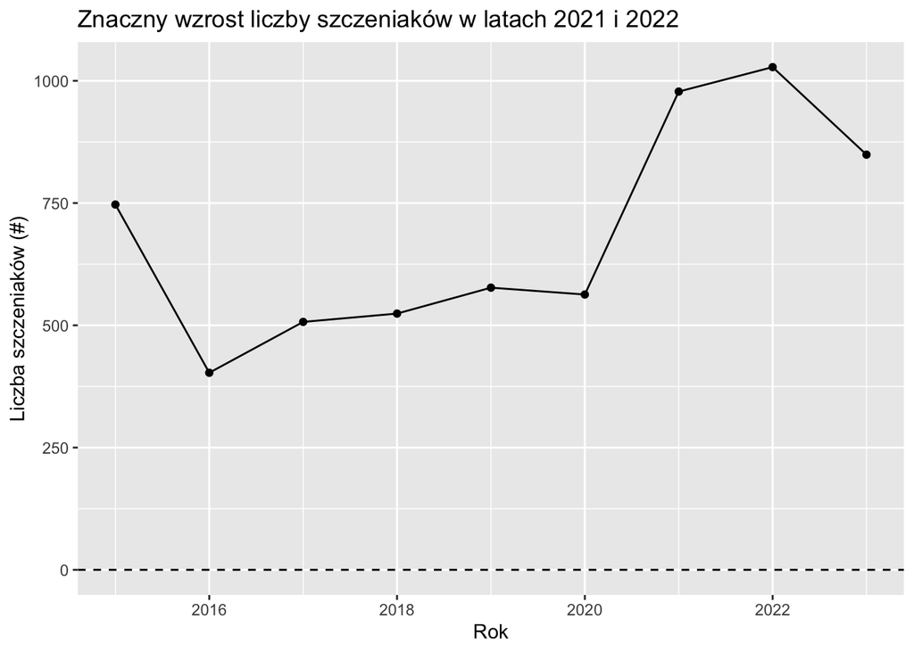

8.1. Wykres: Liczba szczeniaków w Zurychu w latach 2015 - 2023

### 8.2. Populacja szczeniaków w Zurychu w podziale na psy rasowe oraz psy rasy mieszanej

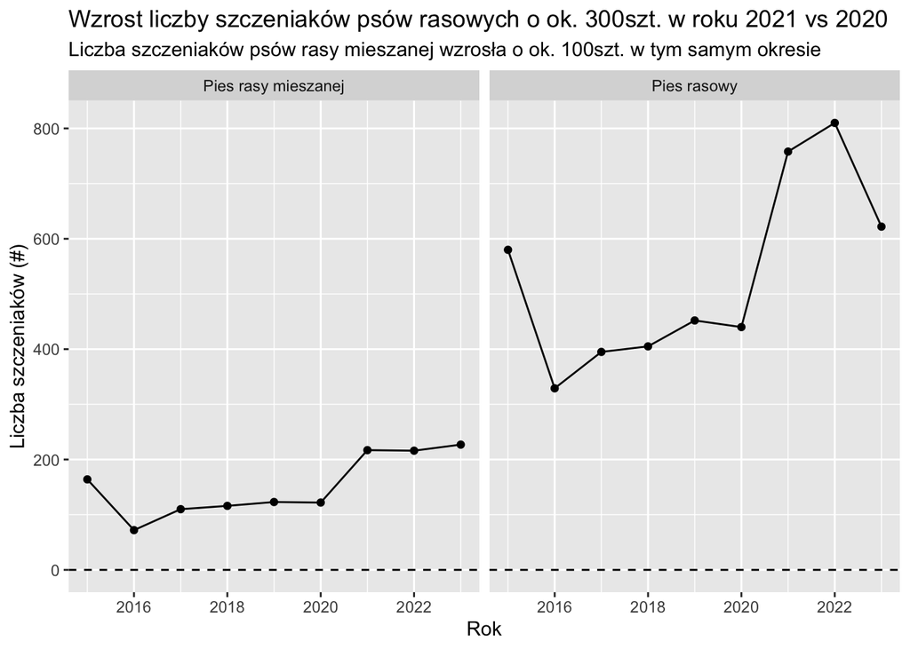

8.2.1. Wykres: Liczba szczeniaków w Zurychu w latach 2015-2023 z podziałem na psy rasowe oraz psy rasy mieszanej

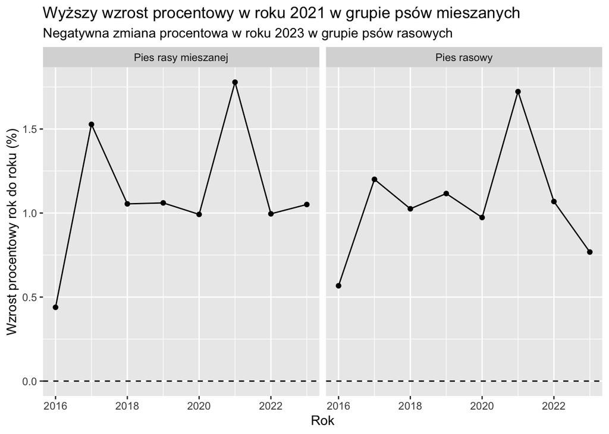

8.2.2. Wykres: Zmiana procentowa liczby szczeniaków w porówaniu do roku poprzedniego

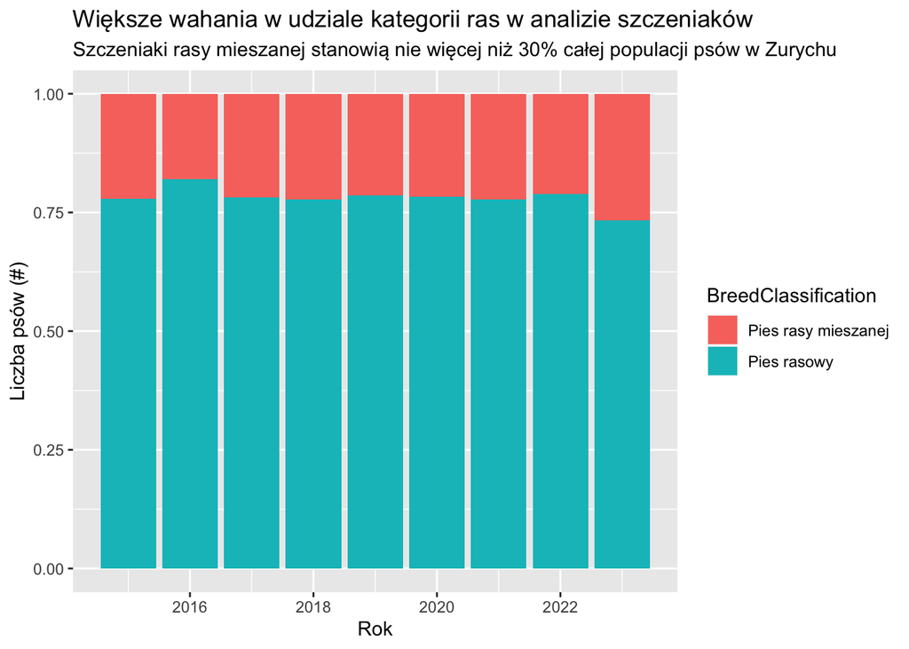

8.2.3. Wykres: Podział populacji psów ze względu na kategorię ras

### 8.3. Populacja szczeniaków w Zurychu w podziale na grupy wiekowe właścicieli - w okresie 2015-2023

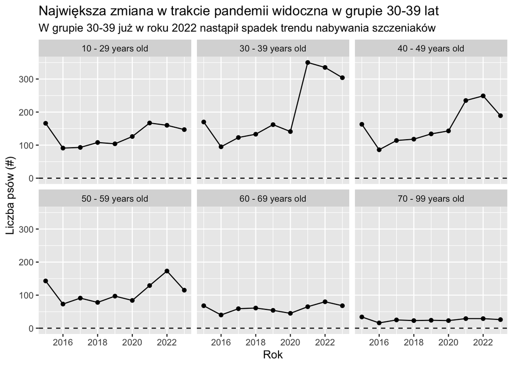

8.3. Wykres: Linia trendu nabywanych szczeniaków przez poszczególne grupy wiekowe

### 8.4. Populacja szczeniaków w Zurychu w podziale na rasy psów - w okresie 2015 - 2023

[figure not shown]

8.4. Wykres: 10 najpopularniejszych ras szczeniaków w roku 2023 przedstawione jako linia trendu w ostatnich latach

#### Wnioski:

Spojrzenie na trend w ilości szczeniaków zdaje się potwierdzać tezę o wzroście liczebności psów ze względu na pandemię. Należy jednocześnie pamiętać, że analizowane są dane psów zarejestrowanych w mieście Zurych - nie można zatem wnioskować, czy w tym czasie znacznie zwiększyła się dostępność (oraz liczebność) szczeniąt w odpowiedzi na zwiększony popyt (należy pamiętać, że pies to istota żywa i są granice tego w jaki sposób podaż może odpowiedzieć na popyt), czy może zmieniła się proporcja jeśli chodzi o nabywców na korzyść mieszkańców miasta Zurych.